**Pouya Sadeghi**

winter-1401(2022)

# AI course, project #5-1

**Neural Network**

In this notebook, we would implement FFNN, train this on Arabic handwritten characters.

# 00. Initialization

```python
import numpy as np
import pandas as pd
import matplotlib.pyplot as plt

from PIL import Image

from sklearn.preprocessing import OneHotEncoder
from sklearn.metrics import accuracy_score

import random
```

```python
from dataclasses import dataclass
```

```python
TRAIN_IMAGES = '../Datasets/TrainImgs.csv'
TRAIN_LABELS = '../Datasets/TrainLabels.csv'

TEST_IMAGES = '../Datasets/TestImgs.csv'
TEST_LABELS = '../Datasets/TestLabels.csv'
```

```python
@dataclass
class Dataset:
    images: pd .DataFrame
    labels: pd.DataFrame

def read_dataset(image_path, label_path):
    images = pd.read_csv(image_path, header=None)
    images = images.astype('uint8')
    labels = pd.read_csv(label_path, header=None)
    labels = labels.astype('uint8')

    return Dataset(images=images, labels=labels)
```

```python
train_dataset = read_dataset(TRAIN_IMAGES, TRAIN_LABELS)
test_dataset = read_dataset(TEST_IMAGES, TEST_LABELS)
```

# 01. Phase 1: Data preprocessing and visualization

## 00. Codes

```python
def show_image(image: pd.Series, description='just an image from the dataset', ax=None):
    coeff = 255 // np.max(image.values)
    image = (image * coeff)
    image = image.astype('int8')
    r_image = image.values.reshape(32, 32)
    img = Image.fromarray(r_image.T, 'L')
    if ax is None:
        plt.figure()
        plt.imshow(img, cmap='gray', vmin=0, vmax=255)
        print(description)
        plt.show()
        print()
        return
    ax.set_title(description)
    ax.imshow(img, cmap='gray', vmin=0, vmax=255)
```

```python
def show_sample_images(df : Dataset):
    total_classes = df.labels[0].unique()
    ncols = 7
    nrows = max((len(total_classes) + ncols - 1) // ncols, 2)
    i, j = ncols, 0
    fig, ax = plt.subplots(ncols=ncols, nrows=nrows, figsize=(10*nrows, 27))
    for label in total_classes:
        i -= 1
        img_idx = list(df.labels[0][df.labels[0] == label].index)
        sample_idx = random.choice(img_idx)
        img = df.images.loc[sample_idx]
        desc = f"sample image with label {label}"
        show_image(image=img, description=desc, ax=ax[j][i])
        if i == 0:
            j += 1
            i = ncols
    plt.show()
```

```python
def check_frequencies(**dfs):
    values_freq = dict()
    total_classes = set()
    total_data_count = 0
    for title, df in dfs.items():
        _values_freq = df.labels[0].value_counts().sort_index()
        plt.bar(_values_freq.index, _values_freq.values, label=title)
        values_freq[title] = _values_freq

        data_count = len(df.labels)
        labels = set(df.labels[0].unique())
        total_data_count += data_count
        total_classes = total_classes.union(labels)
        print(f"{title}:")
        print(f"- total data:    {data_count}")
        print(f"- total classes: {len(labels)}")
        print()

    print("summary report:")
    print(f"- total data:    {total_data_count}")
    print(f"- total classes: {len(total_classes)}")
    print(f"- classes:       {total_classes}")


    plt.legend()
    plt.show()
    return pd.DataFrame(values_freq).T
```

```python
def reduce_by_label(df: Dataset, v_labels):
    valid_idx = []
    for vl in v_labels:
        valid_idx.extend(list(df.labels[0][df.labels[0] == vl].index))
    df.labels = df.labels.iloc[valid_idx]
    df.images = df.images.iloc[valid_idx]
```

```python
def fix_value_range(data: Dataset):
    img = data.images.astype('float64')
#    _min, _max = np.min(img.values), np.max(img.values)
#    if _max != _min:
#       data.images = (img + _min) / (_max - _min)
#    else:

    data.images = img / 255.0
    return data
```

## 01. Show an image of each class

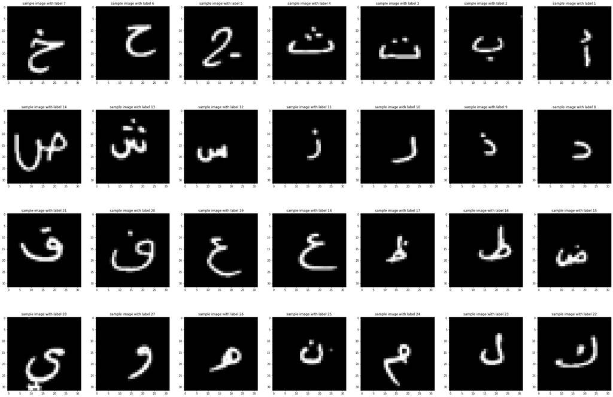

```python
show_sample_images(train_dataset)
```

```python
label_to_char = {
    1: 'ا', 2: 'ب', 3: 'ت', 4: 'ث', 5: 'ج', 6: 'ح', 7: 'خ',
    8: 'د', 9: 'ذ', 10: 'ر', 11: 'ز', 12: 'س', 13: 'ش', 14: 'ص',
    15: 'ض', 16: 'ط', 17: 'ظ', 18: 'ع', 19: 'غ', 20: 'ف', 21: 'ق',
    22: 'ک', 23: 'ل', 24: 'م', 25: 'ن', 26: 'ه', 27: 'و', 28: 'ي',
    }
```

## 02. What is the range of pixel values?

- Their original, $Pixel \in [0, 255]$
- After we changed type to uint8, still $Pixel \in [0, 255]$
- We could also define them as int8, then $Pixel \in [-128, 127]$

```python
np.min(train_dataset.images.values), np.max(train_dataset.images.values)
```

```
(0, 255)
```

## 03. Number of data and classes

- We have 28 class at all
- We have 600 samples for each class $\{Train=480, Test=120\}$
- We have 16800 samples $\{Train=13440, Test=3360\}$

```
train:
- total data:    13440
- total classes: 28

test:
- total data:    3360
- total classes: 28

summary report:
- total data:    16800
- total classes: 28
- classes:       {1, 2, 3, 4, 5, 6, 7, 8, 9, 10, 11, 12, 13, 14, 15, 16, 17, 18, 19, 20, 21, 22, 23, 24, 25, 26, 27, 28}
```

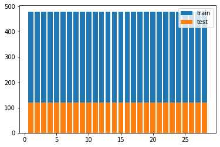

|  | 1 | 2 | 3 | 4 | 5 | 6 | 7 | 8 | 9 | 10 | ... | 19 | 20 | 21 | 22 | 23 | 24 | 25 | 26 | 27 | 28 |
| --- | --- | --- | --- | --- | --- | --- | --- | --- | --- | --- | --- | --- | --- | --- | --- | --- | --- | --- | --- | --- | --- |
| train | 480 | 480 | 480 | 480 | 480 | 480 | 480 | 480 | 480 | 480 | ... | 480 | 480 | 480 | 480 | 480 | 480 | 480 | 480 | 480 | 480 |
| test | 120 | 120 | 120 | 120 | 120 | 120 | 120 | 120 | 120 | 120 | ... | 120 | 120 | 120 | 120 | 120 | 120 | 120 | 120 | 120 | 120 |

2 rows × 28 columns

```python
check_frequencies(train=train_dataset, test=test_dataset)
```

## 04. Filter data

We just keep data that associated with $class \in [1, 16]$

```python
valid_labels = list(range(1,17))
reduce_by_label(train_dataset, valid_labels)
reduce_by_label(test_dataset, valid_labels)
```

## 05. Check data frequencies for each label

- we have 16 class (1 to 16)
- we have 600 samples for each class $\{Train=480, Test=120\}$
- we have 9600 samples $\{Train=7680, Test=1920\}$
- our dataset is balanced, and we don't need to do any things for that purpose.

```
train:
- total data:    7680
- total classes: 16

test:
- total data:    1920
- total classes: 16

summary report:
- total data:    9600
- total classes: 16
- classes:       {1, 2, 3, 4, 5, 6, 7, 8, 9, 10, 11, 12, 13, 14, 15, 16}
```

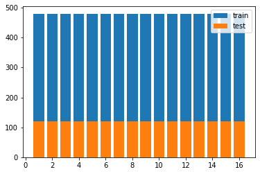

|  | 1 | 2 | 3 | 4 | 5 | 6 | 7 | 8 | 9 | 10 | 11 | 12 | 13 | 14 | 15 | 16 |
| --- | --- | --- | --- | --- | --- | --- | --- | --- | --- | --- | --- | --- | --- | --- | --- | --- |
| train | 480 | 480 | 480 | 480 | 480 | 480 | 480 | 480 | 480 | 480 | 480 | 480 | 480 | 480 | 480 | 480 |
| test | 120 | 120 | 120 | 120 | 120 | 120 | 120 | 120 | 120 | 120 | 120 | 120 | 120 | 120 | 120 | 120 |

```python
check_frequencies(train=train_dataset, test=test_dataset)
```

## 06. Rescale pixel's value

- Scaling is used to set the pixels values in the range of 0 to 1; why?
  - Neural Networks process inputs using small weight values, and inputs with large integer values can disrupt or even slow down the learning process.

```python
train_dataset = fix_value_range(train_dataset)
test_dataset = fix_value_range(test_dataset)
```

```python
print(f"Pixel's value range in Train data: {np.min(train_dataset.images.values), np.max(train_dataset.images.values)}")
print(f"Pixel's value range in Test data: {np.min(test_dataset.images.values), np.max(test_dataset.images.values)}")
```

```
Pixel's value range in Train data: (0.0, 1.0)
Pixel's value range in Test data: (0.0, 1.0)
```

## 07. Encode labels

We use `One Hot Encoding` for this purpose, because:

- having the same amount of loss for miss-classification.
- to prevent our model from considering any ordering(arrangement) for output.

```python
enc = OneHotEncoder()
enc = enc.fit(pd.DataFrame(train_dataset.labels))
train_labels_encoded = pd.DataFrame(enc.transform(train_dataset.labels).toarray(), index=train_dataset.labels.index)
train_labels_encoded.head()
```

|  | 0 | 1 | 2 | 3 | 4 | 5 | 6 | 7 | 8 | 9 | 10 | 11 | 12 | 13 | 14 | 15 |
| --- | --- | --- | --- | --- | --- | --- | --- | --- | --- | --- | --- | --- | --- | --- | --- | --- |
| 0 | 1.0 | 0.0 | 0.0 | 0.0 | 0.0 | 0.0 | 0.0 | 0.0 | 0.0 | 0.0 | 0.0 | 0.0 | 0.0 | 0.0 | 0.0 | 0.0 |
| 1 | 1.0 | 0.0 | 0.0 | 0.0 | 0.0 | 0.0 | 0.0 | 0.0 | 0.0 | 0.0 | 0.0 | 0.0 | 0.0 | 0.0 | 0.0 | 0.0 |
| 2 | 1.0 | 0.0 | 0.0 | 0.0 | 0.0 | 0.0 | 0.0 | 0.0 | 0.0 | 0.0 | 0.0 | 0.0 | 0.0 | 0.0 | 0.0 | 0.0 |
| 3 | 1.0 | 0.0 | 0.0 | 0.0 | 0.0 | 0.0 | 0.0 | 0.0 | 0.0 | 0.0 | 0.0 | 0.0 | 0.0 | 0.0 | 0.0 | 0.0 |
| 4 | 1.0 | 0.0 | 0.0 | 0.0 | 0.0 | 0.0 | 0.0 | 0.0 | 0.0 | 0.0 | 0.0 | 0.0 | 0.0 | 0.0 | 0.0 | 0.0 |

# 02. Phase 2: Implementing FeedForwardNeuralNetwork

## 01. DataLoader

```python
class Dataloader:
    """
    This class prepares the dataset for the neural network.
    """

    def __init__(
        self,
        data: pd.DataFrame,
        labels: pd.DataFrame,
        n_classes: int,
        batch_size: int = None,
        shuffle: bool = False
        ):
        """
        This is the constructor. It gets dataset information and initializes the
        Dataloader class fields.
            Parameters:
                data: features your dataset in pandas.Dataframe format.
                labels: labels of your dataset in pandas.Dataframe format.
                n_classes: number of classes you have in your dataset.
                batch_size: the number of samples that will be propagated through the network.
                shuffle: boolean value indicating whether the dataset should be shuffled
        """

        assert len(data)==len(labels)
        self.__n_classes = n_classes
        self.__batch_size = batch_size
        self.__shuffle = shuffle
        self.__data = data
        self.__onehot_labels = self.__onehot(labels, self.__n_classes)

    @staticmethod
    def __onehot(labels, n_classes):
        """
        This private method gets labels and provides one_hot vectors of labels.
        For categorical variables where no such ordinal relationship exists,
        the integer encoding is not enough.
        In this case, a one-hot encoding can be applied to the integer representation.
        This is where the integer encoded variable is removed, and a new binary variable is
        added for each unique integer value.
        example:
            red,    green,    blue
            1,      0,        0
            0,      1,        0
            0,      0,        1
                Parameters:
                        labels: labels of your dataset in pandas.Dataframe format.
                        n_classes: number of classes you have in your dataset.

                Returns:
                    onehot_vectors: onehot vectors of the labels
        """
        onehot_vectors = pd.DataFrame(OneHotEncoder().fit_transform(labels).toarray(),index=labels.index)
        return onehot_vectors

    def __shuffle_dataset(self):
        """
        This private method shuffles your dataset.
        It uses data and onehot_labels to shuffle them
        symmetrical.
        """
        perm = np.random.permutation(self.__data.shape[0])
        self.__data = self.__data.iloc[perm]
        self.__onehot_labels = self.__onehot_labels.iloc[perm]

    def __iter__(self):
        """
        The __iter__() function returns an iterator for the
        given object (array, set, tuple, etc., or custom objects).
        This will return your dataset in the batch_size given. This should
        be used to provide data for the neural network.
        """

        if self.__shuffle:
            self.__shuffle_dataset()

        if self.__batch_size is None:
            yield np.matrix(self.__data), np.matrix(self.__onehot_labels)
            return

        for idx in range(0, len(self.__data), self.__batch_size):
            yield (np.matrix(self.__data[idx:idx+self.__batch_size]),
                   np.matrix(self.__onehot_labels[idx:idx+self.__batch_size]))
```

## 02. Activation Functions

### 01. Identical

This activation function just return the value it gets.

```python
class Identical:
    """
    This is the Identical activation function. This activation function just
    return the value it gets.
    """

    def __init__(self): pass

    @staticmethod
    def __val(matrix: np.matrix):
        """
        This private method gets a matrix and uses the activity function on that.
        As this is an identical activity function, it just
        returns matrix of the input.

            Parameters:
                matrix: np.matrix of values
            Returns:
                identical_value: np.matrix of input with float datatypes
        """

        identical_value = np.matrix(matrix, dtype=float)
        return identical_value

    @staticmethod
    def derivative(matrix):
        """
        This method returns the derivation of the input.
        As the derivation of x is one, this method returns
        a matrix of one with the shape of the input matrix.

            Parameters:
                matrix: np.matrix of values
            Returns:
                identical_derivative: np.matrix of ones with matrix shape
        """

        identical_derivative = np.matrix(np.full(np.shape(matrix), 1.))
        return identical_derivative

    def __call__(self, matrix):
        """
        __call__ is a special function in Python that, when implemented inside a class,
        gives its instances (objects) the ability to behave like a function.
        Here we return the _value method output.

            Parameters:
                matrix: np.matrix of values
            Returns:
                __val(matrix): __val return value for the input matrix
        """

        return self.__val(matrix)
```

### 02. Relu

Rectified Linear Activation Function(ReLU) is a piecewise linear function that will output the input directly if it is positive, otherwise, it will output zero.

```python
class Relu:
    """
    This is the Relu activation function.
    The rectified linear activation function or ReLU for short
    is a piecewise linear function that will output the input directly
    if it is positive, otherwise, it will output zero.
    """

    def __init__(self): pass

    @staticmethod
    def __val(matrix):
        """
        This private method gets a matrix and uses the activity function on that.
        It will set 0 in the matrix if the value is less than 0 else, it returns the value itself.

            Parameters:
                matrix: np.matrix of values
            Returns:
                relu_value: np.matrix of relu activation function result
        """

        relu_value = np.maximum(0, matrix)
        return relu_value

    @staticmethod
    def derivative(matrix):
        """
        Returns the derivation value of relu function on input matrix.

            Parameters:
                matrix: np.matrix of values
            Returns:
                relu_derivative: np.matrix of relu activation function derivation result
        """

        relu_derivative = np.matrix(np.full(np.shape(matrix), np.where(matrix >= 0, 1, 0)))
        return relu_derivative

    def __call__(self, matrix):
        """
        __call__ is a special function in Python that, when implemented inside a class,
        gives its instances (objects) the ability to behave like a function.
        Here we return the _relu method output.

            Parameters:
                matrix: np.matrix of values
            Returns:
                __relu(matrix): __relu return value for the input matrix
        """

        return self.__val(matrix)
```

### 03. LeakyRelu

Leaky Rectified Linear Unit(Leaky ReLU) is a type of activation function based on a ReLU, but it has a small slope for negative values instead of a flat slope.

```python
class LeakyRelu:
    """
    This is the Leaky Relu activation function.
    Leaky Rectified Linear Unit, or Leaky ReLU,
    is a type of activation function based on a ReLU,
    but it has a small slope for negative values instead
    of a flat slope.
    """

    def __init__(self, negative_slope=0.01):
        self.negative_slope = negative_slope

    def __val(self, matrix):
        """
        This private method gets a matrix and uses the activity function on that.
        It will set negative_slope*value in the matrix if the value is less than 0, else it
        returns the value itself.

            Parameters:
                matrix: np.matrix of values
            Returns:
                relu_value: np.matrix of relu activation function result
        """

        temp = np.matrix(matrix, dtype=float)
        leaky_relu_value = np.where(temp < 0, temp * self.negative_slope, temp)
        return leaky_relu_value

    def derivative(self, matrix):
        """
        Returns the derivation value of leaky relu function on input matrix.

            Parameters:
                matrix: np.matrix of values
            Returns:
                leaky_relu_derivative: np.matrix of leaky relu activation function derivation result
        """

        leaky_relu_derivative = np.matrix(np.full(np.shape(matrix), np.where(matrix >= 0, 1, self.negative_slope)))
        return leaky_relu_derivative

    def __call__(self, matrix):
        """
        __call__ is a special function in Python that, when implemented inside a class,
        gives its instances (objects) the ability to behave like a function.
        Here we return the _val method output.

            Parameters:
                matrix: np.matrix of values
            Returns:
                __val(matrix): __val return value for the input matrix
        """

        return self.__val(matrix)
```

### 04. Sigmoid

It is a mathematical function having a characteristic "S"-shaped curve or sigmoid curve. It returns $S(x)= \frac{1}{1+\exp^{-x}}$

```python
class Sigmoid:
    """
    A sigmoid function is a mathematical function having a
    characteristic "S"-shaped curve or sigmoid curve.
    It returns S(x)=1/(1+e^-x)
    """

    def __init__(self): pass

    @staticmethod
    def __val(matrix):
        """
        Returns 1/(1+e^-x) of values

            Parameters:
                matrix: np.matrix of values
            Returns:
                sigmoid_value: np.matrix of relu activation function result
        """
        temp = np.matrix(matrix, dtype=float)
        sigmoid_value = 1 / (1 + np.exp(-temp))
        return sigmoid_value

    def derivative(self, matrix):
        """
        Returns the derivation value of sigmoid function on input matrix.

            Parameters:
                matrix: np.matrix of values
            Returns:
                sigmoid_derivative: np.matrix of sigmoid activation function derivation result
        """
        sig = self.__val(matrix)
        sigmoid_derivative = np.multiply(sig, (1 - sig))
        return sigmoid_derivative

    def __call__(self, matrix):
        """
        __call__ is a special function in Python that, when implemented inside a class,
        gives its instances (objects) the ability to behave like a function.
        Here we return the _val method output.

            Parameters:
                matrix: np.matrix of values
            Returns:
                __val(matrix): __val return value for the input matrix
        """
        return self.__val(matrix)
```

### 05. Softmax

It is a generalization of the logistic function to multiple dimensions. It is used in multinomial logistic regression and is often used as the last activation function of a neural network to normalize the output of a network to a probability distribution over predicted output classes, based on Luce's choice axiom. Softmax returns ${\frac{e^{x_i}}{\sum{e^{x_i}}}}$.

Attention: we use `stable softmax` to avoid this issue.

```python
def soft_max_util(row):
    """helping to applying stable softmax"""
    nmd = np.exp(row - np.max(row))
    denominator = np.sum(nmd)
    ssm = nmd / denominator
    return ssm


class Softmax:
    """
    The softmax function, also known as soft argmax  or normalized
    exponential function is a generalization of the logistic
    function to multiple dimensions. It is used in multinomial logistic
    regression and is often used as the last activation function of a neural
    network to normalize the output of a network to a probability distribution
    over predicted output classes, based on Luce's choice axiom.
    Softmax return (e^x_i / (Σe^x_j for j = 1, ..., J))
    """

    def __init__(self): pass

    @staticmethod
    def __val(matrix):
        """
        This private method gets a matrix and uses the softmax on that.
        Softmax return (e^x_i / (Σe^x_j for j = 1, ..., J))

            Parameters:
                matrix: np.matrix of values
            Returns:
                relu_value: np.matrix of relu activation function result
        """
        e = np.exp(matrix - np.max(matrix))
        return e / e.sum(axis=1).reshape([matrix.shape[0], 1])
        # return np.apply_along_axis(soft_max_util, 1, matrix)

    def __call__(self, matrix):
        """
        __call__ is a special function in Python that, when implemented inside a class,
        gives its instances (objects) the ability to behave like a function.
        Here we return the _val method output.

            Parameters:
                matrix: np.matrix of values
            Returns:
                __val(matrix): __val return value for the input matrix
        """

        return self.__val(matrix)
```

```python
class Tanh:

    def __init__(self): pass

    @staticmethod
    def __val(matrix):
        """
        This private method gets a matrix and uses the activity function on that.
        It performs Tanh on the values.

            Parameters:
                matrix: np.matrix of values
            Returns:
                tanh_value: np.matrix of Tanh activation function result
        """

        temp = np.matrix(matrix, dtype=float)
        tanh_value = np.tanh(temp)
        return tanh_value

    def derivative(self, matrix):
        """
        Returns the derivation value of Tanh function on input matrix.

            Parameters:
                matrix: np.matrix of values
            Returns:
                sigmoid_derivative: np.matrix of Tanh activation function derivation result
        """

        tanh_derivative = 1 - np.power(self.__val(matrix), 2)
        return tanh_derivative

    def __call__(self, matrix):
        """
        __call__ is a special function in Python that, when implemented inside a class,
        gives its instances (objects) the ability to behave like a function.
        Here we return the _val method output.

            Parameters:
                matrix: np.matrix of values
            Returns:
                __val(matrix): __val return value for the input matrix
        """

        return self.__val(matrix)
```

## 03. Loss Function

We use cross entropy with softmax as loss function.

Cross-entropy is a measure of the difference between two probability distributions for a given random variable or set of events. You might recall that information quantifies the number of bits required to encode and transmit an event.

```python
class CrossEntropy:
    """
    Cross-entropy is a measure of the difference between two probability
    distributions for a given random variable or set of events. You might
    recall that information quantifies the number of bits required to encode
    and transmit an event.
    """

    def __init__(self):
        self.softmax = Softmax()

    def __val(self, true_val, expected_val):
        """
        L(y^, y) = - Σ (y^(k)log (y^)^(k)) for k in K
        Parameters:
            true_val: calculated values (generated by neural network)
            expected_val: real values in dataset
        Returns:
            cross_entropy_value: cross entropy of inputs
        """

        assert np.shape(true_val) == np.shape(expected_val)

        generated = np.log(self.softmax(true_val))
        cross_entropy_value =  np.sum(-np.multiply(expected_val, generated), axis=1)

        return cross_entropy_value

    def derivative(self, true_val, expected_val):
        """
        Returns derivation of cross entropy.
            Parameters:
                true_val: calculated values (generated by neural network)
                expected_val: real values in dataset
            Returns:
                cross_entropy_derivative: cross entropy derivation of inputs
        """

        assert np.shape(true_val)==np.shape(expected_val)

        generated = self.softmax(true_val)
        cross_entropy_derivative = generated - expected_val

        return cross_entropy_derivative

    def __call__(self, true_val, expected_val):
        """
        __call__ is a special function in Python that, when implemented inside a class,
        gives its instances (objects) the ability to behave like a function.
        Here we return the _val method output.

            Parameters:
                true_val: calculated values (generated by neural network)
                expected_val: real values in dataset
            Returns:
                __val(matrix): __val return value for the input matrix
        """

        return self.__val(true_val, expected_val)
```

## 04. Layer

```python
class Layer:
    """
    The layer class is used to define neural network layers.
    It stores all needed information for each layer, such as neurons count,
    weight matrix, bias, the output after applying the activation function, etc.
    """

    DEFAULT_LOW = 0
    DEFAULT_HIGH = 0.05
    DEFAULT_MEAN = 0.0
    DEFAULT_VAR = 1.0

    def __init__(self, input_size, output_size, activation=Identical(), initial_weight='uniform',
                 **initializing_parameters):
        """
        Parameters:
            input_size: the size of the input of this layer.
            output_size: the size of the output after this layer.
            activation: the activation function. It can be initialized to either of the previously defined activation classes.
                               default is an Identical activation function.
            initial_weight: either normal or uniform. It defines the method for weight initialization.
        """

        assert type(initial_weight)==str, 'Undefined activation function!'

        self.__weight_initializer_dict = {'uniform':self.__uniform_weight, 'normal':self.__normal_weight, 'zero': self.__zero_weight}

        assert initial_weight in self.__weight_initializer_dict, 'Undefined weight initialization function!'


        self.__n_neurons = output_size
        weight_initializer = self.__weight_initializer_dict[initial_weight]
        self.__weight = weight_initializer(input_size, self.__n_neurons, **initializing_parameters)
        self.__bias = weight_initializer(1, self.__n_neurons, **initializing_parameters)
        self.__activation = activation

        self.__last_input = None
        self.__last_activation_input = None
        self.__last_activation_output = None
        self.__last_activation_derivative = None

    def forward(self, layer_input):
        """
        It calculates the output of this layer for the layer_input argument.
        This method also stores __last_input, __last_activation_input, and __last_activation_derivative
        for future use in backpropagation.
        Parameters:
            layer_input: 2d np.matrix representing the input matrix of this layer.
        Returns:
            Final output of this layer after applying the activation function.
        """

        assert np.ndim(layer_input) == 2
        assert np.size(self.__weight, 0) == np.size(layer_input, 1)

        # storing the input for back-propagation
        self.__last_input = np.matrix(layer_input, dtype=float)

        # calculating input and output of activation and output's derivation
        self.__last_activation_input = np.add(np.dot(self.__last_input, self.__weight), self.__bias)
        self.__last_activation_output = self.__activation(self.__last_activation_input)
        self.__last_activation_derivative = self.__activation.derivative(self.__last_activation_input)

        return self.__last_activation_output

    def update_weights(self, backprop_tensor, lr):
        """
        It updates Layer weights according to the backpropagation matrix and learning rate.
        This method updates bias values as well.
        Parameters:
            backprop_tensor: 2d np.matrix passed from the next layer containing gradient values.
            lr: learning rate
        Returns:
            backprop_tensor to be used by the previous layer.
        """

        assert np.ndim(backprop_tensor)==2
        assert np.size(backprop_tensor,0) == np.size(self.__last_activation_derivative,0)
        assert np.size(backprop_tensor,1) == self.__n_neurons

        ones = np.matrix(np.ones((1, np.size(backprop_tensor,axis=0))))
        dy = np.multiply(backprop_tensor, self.__last_activation_derivative)
        db = np.matmul(ones, dy)
        dw = np.matmul(self.__last_input.T, dy)

        backprop_tensor = np.matmul(dy, self.__weight.T)

        self.__weight -= lr * dw
        self.__bias -= lr * db

        return backprop_tensor

    def __uniform_weight(self, dim1, dim2, **initializing_parameters):
        """
        Initializes weights as a uniform distribution between low and high values.
        It uses default low and high values unless low or high are passed in initializing_parameters.
        Parameters:
            dim1: the size of the first dimension of weights.
            dim2: the size of the second dimension of weights.
            initializing_parameters: other initializing parameters; it can include custom low or high values.
        Returns:
            np.matrix with size (dim1, dim2) initialized using uniformly distributed values.
        """

        low = self.DEFAULT_LOW
        high = self.DEFAULT_HIGH
        if 'low' in initializing_parameters.keys(): low = initializing_parameters['low']
        if 'high' in initializing_parameters.keys(): high = initializing_parameters['high']
        weights = np.matrix(np.random.uniform(low=low, high=high, size=(dim1, dim2)))

        return weights

    def __normal_weight(self, dim1, dim2, **initializing_parameters):
        """
        Initializes weights as a normal distribution with mean and var values.
        It uses default mean and variance values unless mean or var are passed in initializing_parameters.
        Parameters:
            dim1: the size of the first dimension of weights.
            dim2: the size of the second dimension of weights.
            initializing_parameters: other initializing parameters; it can include custom mean or var values.
        Returns:
            np.matrix with size (dim1, dim2) initialized using normally distributed values.
        """

        mean = self.DEFAULT_MEAN
        var = self.DEFAULT_VAR
        if 'mean' in initializing_parameters.keys(): mean = initializing_parameters['mean']
        if 'var' in initializing_parameters.keys(): var = initializing_parameters['var']
        weights = np.matrix(np.random.normal(loc = mean, scale = np.sqrt(var), size=(dim1, dim2)))

        return weights

    def __zero_weight(self, dim1, dim2, **initializing_parameters):
        """Initializes weights to zero"""
        return np.zeros(shape=(dim1, dim2))

    @property
    def n_neurons(self):
        return self.__n_neurons

    @property
    def weight(self):
        return self.__weight

    @property
    def bias(self):
        return self.__bias

    @property
    def activation(self):
        return self.__activation
```

## 05. Feed Forward Neural Network

```python
class FeedForwardNeuralNetwork:
    """
    This class is used in order to implement custom feed-forward neural networks.
    The FeedForwardNN class stores a list of layers that determines all network layers.
    It also consists of the learning rate and loss function.
    """
    def __init__(self, input_shape: int):
        """
        Parameters:
            input_shape: the size of the first input to our neural network.
        """

        self.__input_shape: int = input_shape
        self.__output_shape: int = None

        self.__layers_list: list[Layer] = []

        self.__lr: int = None
        self.__loss = None


    def add_layer(self, n_neurons, activation=Relu(), initial_weight='uniform', **initializing_parameters):
        """
         This method adds a new custom layer to the layers_list.
         Parameters:
             n_neurons: number of neurons in this layer
             activation: the activation function of this layer, default is Relu
             initial_weight: either a uniform or normal, default is uniform
             initializing_parameters: other initializing parameters such as low, high, mean, var, etc
        """

        assert type(n_neurons)==int, "Invalid number of neurons for the layer!"
        assert n_neurons>0, "Invalid number of neurons for the layer!"

        n_prev_neurons = self.__input_shape if len(self.__layers_list) == 0 else self.__layers_list[-1].n_neurons
        new_layer = Layer(n_prev_neurons, n_neurons, activation, initial_weight, **initializing_parameters)
        self.__layers_list.append(new_layer)
        self.__output_shape = self.__layers_list[-1].n_neurons


    def set_training_param(self, loss=CrossEntropy(), lr=1e-3):
        """
        This method is used to set training parameters.
        Parameters:
            loss: loss function, default is CrossEntropy
            lr: learning rate, default is 1e-3
        """

        assert self.__layers_list, "Uncompleted model!"
        self.__loss = loss
        self.__lr = lr


    def forward(self, network_input):
        """
        This method calculates the output of the complete neural network for a passed input.
        Parameters:
            network_input: input of the neural network
        Returns:
            network_output: output of the neural network after forwarding the network_input
        """

        assert self.__output_shape is not None, "Model is not compiled!"

        network_output = network_input
        for layer in self.__layers_list:
            network_output = layer.forward(network_output)
        return network_output


    def fit(self, epochs, train_loader: Dataloader, test_loader: Dataloader = None, print_results=True):
        """
        This method trains the neural network using specified parameters.
        It runs the __train private method epoch times and fills the log dictionary.
        Parameters:
            epochs: number of epochs to run
            train_loader: DataLoader for train data
            test_loader: DataLoader for test data
            print_results: whether to print the results
        Returns:
            log: complete log of the training process as a dictionary consisting of
            train_accuracy, train_loss, test_accuracy, test_loss
        """

        assert self.__output_shape is not None, "Model is not compiled!"
        assert (self.__lr is not None) and (self.__loss is not None), "Training parameters are not set!"

        log = {"train_accuracy":[], "train_loss":[], "test_accuracy":[], "test_loss":[]}

        for epoch in range(1, epochs+1):

            if print_results:
                res = f"Epoch #{epoch}\n"

            average_accuracy, average_loss = self.__train(train_loader)
            log['train_accuracy'].append(average_accuracy)
            log['train_loss'].append(average_loss)
            if print_results:
                res += f'\tTrain: Average Accuracy: {average_accuracy:.1f}%\tAverage Loss: {average_loss:.1f}\n'

            if test_loader is not None:
                average_accuracy, average_loss = self.__test(test_loader)
                log['test_accuracy'].append(average_accuracy)
                log['test_loss'].append(average_loss)
                if print_results:
                    res += f'\tTest:  Average Accuracy: {average_accuracy:.1f}%\tAverage Loss: {average_loss:.1f}'
                    print(res)

        return log


    def __train(self, train_loader: Dataloader):
        """
        Trains the neural network for one epoch.
        Parameters:
            train_loader: A DataLoader consisting of train data
        Returns:
            batch_accuracy, batch_loss: mean of all batch_accuracies, batch_losses
        """

        bach_accuracies, batch_losses = [], []
        for x_train, y_train in train_loader:
            batch_accuracy, batch_loss = self.__train_on_batch(x_train, y_train)
            bach_accuracies.append(batch_accuracy)
            batch_losses.append(batch_loss)
        return np.mean(bach_accuracies), np.mean(batch_losses)


    def __test(self, test_loader: Dataloader):
        """
        Test the neural network using a test_loader.
        Parameters:
            test_loader: A DataLoader of test data
        Returns:
            batch_accuracy, batch_loss: mean of all batch_accuracies, batch_losses
        """

        bach_accuracies, batch_losses = [], []
        for x_test, y_test in test_loader:
            batch_accuracy, batch_loss = self.__test_on_batch(x_test, y_test)
            bach_accuracies.append(batch_accuracy)
            batch_losses.append(batch_loss)
        return np.mean(bach_accuracies), np.mean(batch_losses)


    def __train_on_batch(self, x_batch, y_batch):
        """
        Trains the neural network for one batch of train data.
        Parameters:
            x_batch: one batch data
            y_batch: labels for one batch
        Returns:
            (batch_accuracy, batch_average_loss)
        """

        nn_result = self.forward(x_batch)

        batch_accuracy = self.__compute_accuracy(nn_result, y_batch)
        batch_average_loss = np.mean(self.__loss(nn_result, y_batch))

        self.__update_weights(nn_result, y_batch)

        return batch_accuracy, batch_average_loss


    def __test_on_batch(self, x_batch, y_batch):
        """
        Tests the neural network for one batch of test data.
        Parameters:
            x_batch: one batch data
            y_batch: labels for one batch
        Returns:
            (batch_accuracy, batch_average_loss)
        """

        nn_result = self.forward(x_batch)

        batch_accuracy = self.__compute_accuracy(nn_result, y_batch)
        batch_average_loss = np.mean(self.__loss(nn_result, y_batch))

        return batch_accuracy, batch_average_loss


    @staticmethod
    def __get_labels(outputs):
        """
        Parameters:
            outputs: output of the neural network
        Returns:
            labels: labels generated from the outputs of the neural network
        """

        labels = np.argmax(outputs, 1)
        return labels


    def __compute_accuracy(self, output, expected_output):
        """
        Computes accuracy by comparing output and expected_output.
        Parameters:
            output: actual output of the neural network
            expected_output: expected output
        Returns:
            accuracy
        """

        labels = self.__get_labels(output)
        expected_labels = self.__get_labels(expected_output)
        accuracy = 100 * accuracy_score(expected_labels, labels)
        return accuracy


    def __update_weights(self, output, y_train):
        """
        Updates weights of all layers according to neural network output and labels.
        Parameters:
            output: output of the neural network
            y_train: y labels for one batch of train data
        Returns:
            None
        """

        back_propagation_tensor = self.__loss.derivative(output, y_train)
        for layer in reversed(self.__layers_list):
            back_propagation_tensor = layer.update_weights(back_propagation_tensor, self.__lr)
        return
```

# 03. Phase 3: Data Classification

```python
def plot_logs(logs : dict):
    fig, ax = plt.subplots(1, 2, figsize=(13, 5))
    ax[0].set_title('Accuracy')
    ax[0].set_ylabel('Accuracy (%)')
    ax[0].set_xlabel('Epoch')
    ax[0].plot(logs['train_accuracy'], label='Train')
    ax[0].plot(logs['test_accuracy'], label='Test')
    ax[0].legend()

    ax[1].set_title('Loss')
    ax[1].set_ylabel('Loss')
    ax[1].set_xlabel('Epoch')
    ax[1].plot(logs['train_loss'], label='Train')
    ax[1].plot(logs['test_loss'], label='Test')
    ax[1].legend()

    plt.show()
```

## 01. Designing NeuralNetwork

```python
INPUT_SHAPE = 32 * 32
LEARNING_RATE = 0.005
EPOCHS = 100
BATCH_SIZE = 32
N_CLASSES = 16
```

```python
TRAIN_LOADER = Dataloader(data=train_dataset.images, labels=train_dataset.labels, n_classes=N_CLASSES, batch_size=BATCH_SIZE, shuffle=True)
TEST_LOADER = Dataloader(data=test_dataset.images, labels=test_dataset.labels, n_classes=N_CLASSES, batch_size=BATCH_SIZE, shuffle=False)
```

## 02. Generate Network

```python
network = FeedForwardNeuralNetwork(INPUT_SHAPE)

network.add_layer(n_neurons=50, activation=Relu(), initial_weight='uniform')
network.add_layer(n_neurons=90, activation=Relu(), initial_weight='uniform')
network.add_layer(n_neurons=N_CLASSES, activation=Identical(), initial_weight='uniform')
network.set_training_param(loss=CrossEntropy(), lr=LEARNING_RATE)
```

## 03. Train Network

```python
log = network.fit(epochs=EPOCHS, train_loader=TRAIN_LOADER, test_loader=TEST_LOADER, print_results=True)
```

```
Epoch #1
	Train: Average Accuracy: 10.0%	Average Loss: 2.7
	Test:  Average Accuracy: 12.9%	Average Loss: 2.5
Epoch #2
	Train: Average Accuracy: 17.2%	Average Loss: 2.3
	Test:  Average Accuracy: 25.6%	Average Loss: 2.0
Epoch #3
	Train: Average Accuracy: 29.5%	Average Loss: 1.9
	Test:  Average Accuracy: 35.2%	Average Loss: 1.7
Epoch #4
	Train: Average Accuracy: 35.2%	Average Loss: 1.7
	Test:  Average Accuracy: 35.0%	Average Loss: 1.6
Epoch #5
	Train: Average Accuracy: 46.4%	Average Loss: 1.4
	Test:  Average Accuracy: 47.3%	Average Loss: 1.4
Epoch #6
	Train: Average Accuracy: 51.7%	Average Loss: 1.2
	Test:  Average Accuracy: 56.4%	Average Loss: 1.2
Epoch #7
	Train: Average Accuracy: 56.4%	Average Loss: 1.1
	Test:  Average Accuracy: 58.4%	Average Loss: 1.1
Epoch #8
	Train: Average Accuracy: 61.1%	Average Loss: 1.0
	Test:  Average Accuracy: 57.7%	Average Loss: 1.1
Epoch #9
	Train: Average Accuracy: 64.3%	Average Loss: 0.9
	Test:  Average Accuracy: 61.8%	Average Loss: 1.0
Epoch #10
	Train: Average Accuracy: 66.8%	Average Loss: 0.8
	Test:  Average Accuracy: 60.7%	Average Loss: 1.0
Epoch #11
	Train: Average Accuracy: 69.0%	Average Loss: 0.8
	Test:  Average Accuracy: 66.7%	Average Loss: 0.9
Epoch #12
	Train: Average Accuracy: 70.8%	Average Loss: 0.7
	Test:  Average Accuracy: 64.9%	Average Loss: 0.9
Epoch #13
	Train: Average Accuracy: 73.5%	Average Loss: 0.7
	Test:  Average Accuracy: 65.6%	Average Loss: 0.9
Epoch #14
```

[output cut: 245 more lines]

```
Epoch #96
	Train: Average Accuracy: 100.0%	Average Loss: 0.0
	Test:  Average Accuracy: 76.8%	Average Loss: 1.7
Epoch #97
	Train: Average Accuracy: 100.0%	Average Loss: 0.0
	Test:  Average Accuracy: 76.8%	Average Loss: 1.7
Epoch #98
	Train: Average Accuracy: 100.0%	Average Loss: 0.0
	Test:  Average Accuracy: 76.9%	Average Loss: 1.8
Epoch #99
	Train: Average Accuracy: 100.0%	Average Loss: 0.0
	Test:  Average Accuracy: 76.9%	Average Loss: 1.8
Epoch #100
	Train: Average Accuracy: 100.0%	Average Loss: 0.0
	Test:  Average Accuracy: 76.9%	Average Loss: 1.8
```

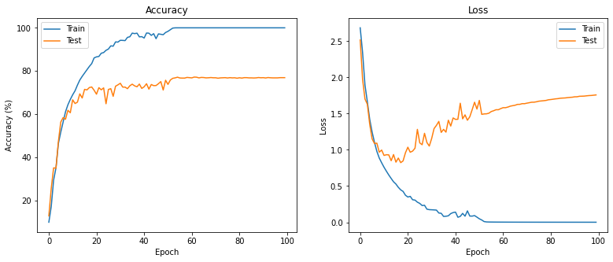

```python
plot_logs(log)
```

## 04. Parameter's effect

```python
def test_network_config(l_r=LEARNING_RATE, active=Relu, init_weight='uniform', epoch=EPOCHS, out=True, plot=True, ret_acc=False, loader=(TRAIN_LOADER,TEST_LOADER)):
    network = FeedForwardNeuralNetwork(INPUT_SHAPE)

    network.add_layer(n_neurons=50, activation=active(), initial_weight=init_weight)
    network.add_layer(n_neurons=90, activation=active(), initial_weight=init_weight)
    network.add_layer(n_neurons=N_CLASSES, activation=Identical(), initial_weight=init_weight)
    network.set_training_param(loss=CrossEntropy(), lr=l_r)

    log = network.fit(epochs=epoch, train_loader=loader[0], test_loader=loader[1], print_results=out)
    if plot:
        plot_logs(log)
    if ret_acc:
        return {'train': log['train_accuracy'][-1] , 'test': log['test_accuracy'][-1]}
```

### 01. Weights initialization

What if we used zero values as layers' weight initial value?

In this case:

- the derivatives will remain the same
- neural network can't learn features
- this leads to convergence interruption, because gradient decent can't update weights
  - due to `backprop_tensor = np.matmul(dy, self.__weight.T)`, *backprop_tensor* would became zero
  - so, GD can't help optimizing model
- issue exist if we use same constant value to initialization and all nodes, would send the same signal ($InputSum * Const$) [called symmetric problem]
- no matter what was the input, if all weights are the same, all units in hidden layer will be the same too.
- so, we use random initialization to Break symmetry

```
Epoch #1
	Train: Average Accuracy: 5.7%	Average Loss: 2.8
	Test:  Average Accuracy: 6.2%	Average Loss: 2.8
Epoch #2
	Train: Average Accuracy: 5.8%	Average Loss: 2.8
	Test:  Average Accuracy: 6.2%	Average Loss: 2.8
Epoch #3
	Train: Average Accuracy: 5.9%	Average Loss: 2.8
	Test:  Average Accuracy: 6.2%	Average Loss: 2.8
Epoch #4
	Train: Average Accuracy: 6.0%	Average Loss: 2.8
	Test:  Average Accuracy: 6.2%	Average Loss: 2.8
Epoch #5
	Train: Average Accuracy: 6.1%	Average Loss: 2.8
	Test:  Average Accuracy: 6.2%	Average Loss: 2.8
Epoch #6
	Train: Average Accuracy: 6.0%	Average Loss: 2.8
	Test:  Average Accuracy: 6.2%	Average Loss: 2.8
Epoch #7
	Train: Average Accuracy: 5.8%	Average Loss: 2.8
	Test:  Average Accuracy: 6.2%	Average Loss: 2.8
Epoch #8
	Train: Average Accuracy: 5.9%	Average Loss: 2.8
	Test:  Average Accuracy: 6.2%	Average Loss: 2.8
Epoch #9
	Train: Average Accuracy: 5.9%	Average Loss: 2.8
	Test:  Average Accuracy: 6.2%	Average Loss: 2.8
Epoch #10
	Train: Average Accuracy: 5.4%	Average Loss: 2.8
	Test:  Average Accuracy: 6.2%	Average Loss: 2.8
Epoch #11
	Train: Average Accuracy: 5.8%	Average Loss: 2.8
	Test:  Average Accuracy: 6.2%	Average Loss: 2.8
Epoch #12
	Train: Average Accuracy: 5.4%	Average Loss: 2.8
	Test:  Average Accuracy: 6.2%	Average Loss: 2.8
Epoch #13
	Train: Average Accuracy: 6.0%	Average Loss: 2.8
	Test:  Average Accuracy: 6.2%	Average Loss: 2.8
Epoch #14
```

[output cut: 245 more lines]

```
Epoch #96
	Train: Average Accuracy: 6.2%	Average Loss: 2.8
	Test:  Average Accuracy: 6.2%	Average Loss: 2.8
Epoch #97
	Train: Average Accuracy: 5.7%	Average Loss: 2.8
	Test:  Average Accuracy: 6.2%	Average Loss: 2.8
Epoch #98
	Train: Average Accuracy: 5.9%	Average Loss: 2.8
	Test:  Average Accuracy: 6.2%	Average Loss: 2.8
Epoch #99
	Train: Average Accuracy: 6.0%	Average Loss: 2.8
	Test:  Average Accuracy: 6.2%	Average Loss: 2.8
Epoch #100
	Train: Average Accuracy: 6.2%	Average Loss: 2.8
	Test:  Average Accuracy: 6.2%	Average Loss: 2.8
```

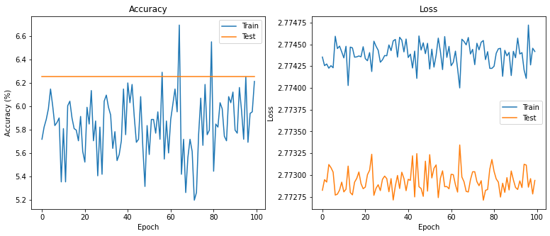

```python
test_network_config(init_weight='zero')
```

### 02. Leaning rate

We will consider three cases here:

#### 01. lower learning rate

```
Epoch #1
	Train: Average Accuracy: 5.7%	Average Loss: 2.8
	Test:  Average Accuracy: 6.2%	Average Loss: 2.7
Epoch #2
	Train: Average Accuracy: 6.2%	Average Loss: 2.7
	Test:  Average Accuracy: 6.3%	Average Loss: 2.7
Epoch #3
	Train: Average Accuracy: 6.7%	Average Loss: 2.7
	Test:  Average Accuracy: 6.7%	Average Loss: 2.7
Epoch #4
	Train: Average Accuracy: 7.5%	Average Loss: 2.7
	Test:  Average Accuracy: 8.2%	Average Loss: 2.7
Epoch #5
	Train: Average Accuracy: 8.9%	Average Loss: 2.7
	Test:  Average Accuracy: 10.3%	Average Loss: 2.7
Epoch #6
	Train: Average Accuracy: 10.6%	Average Loss: 2.6
	Test:  Average Accuracy: 10.9%	Average Loss: 2.6
Epoch #7
	Train: Average Accuracy: 11.3%	Average Loss: 2.6
	Test:  Average Accuracy: 12.0%	Average Loss: 2.6
Epoch #8
	Train: Average Accuracy: 13.3%	Average Loss: 2.6
	Test:  Average Accuracy: 14.4%	Average Loss: 2.6
Epoch #9
	Train: Average Accuracy: 18.4%	Average Loss: 2.5
	Test:  Average Accuracy: 19.6%	Average Loss: 2.5
Epoch #10
	Train: Average Accuracy: 20.0%	Average Loss: 2.4
	Test:  Average Accuracy: 21.6%	Average Loss: 2.3
Epoch #11
	Train: Average Accuracy: 22.3%	Average Loss: 2.3
	Test:  Average Accuracy: 23.4%	Average Loss: 2.2
Epoch #12
	Train: Average Accuracy: 23.5%	Average Loss: 2.2
	Test:  Average Accuracy: 25.7%	Average Loss: 2.1
Epoch #13
	Train: Average Accuracy: 25.8%	Average Loss: 2.1
	Test:  Average Accuracy: 25.7%	Average Loss: 2.0
Epoch #14
```

[output cut: 245 more lines]

```
Epoch #96
	Train: Average Accuracy: 78.6%	Average Loss: 0.6
	Test:  Average Accuracy: 66.9%	Average Loss: 1.0
Epoch #97
	Train: Average Accuracy: 78.7%	Average Loss: 0.6
	Test:  Average Accuracy: 67.7%	Average Loss: 0.9
Epoch #98
	Train: Average Accuracy: 79.1%	Average Loss: 0.6
	Test:  Average Accuracy: 67.4%	Average Loss: 0.9
Epoch #99
	Train: Average Accuracy: 79.4%	Average Loss: 0.5
	Test:  Average Accuracy: 68.2%	Average Loss: 0.9
Epoch #100
	Train: Average Accuracy: 79.6%	Average Loss: 0.5
	Test:  Average Accuracy: 67.0%	Average Loss: 0.9
```

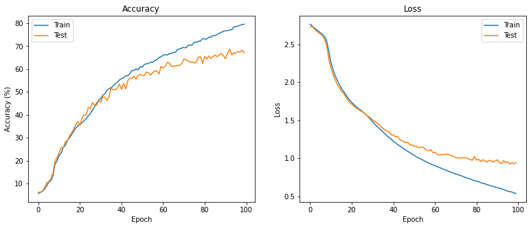

```python
test_network_config(l_r=LEARNING_RATE * 0.1)
```

#### 02. higher learning rate

```
Epoch #1
	Train: Average Accuracy: 6.1%	Average Loss: 3.0
	Test:  Average Accuracy: 6.2%	Average Loss: 2.8
Epoch #2
	Train: Average Accuracy: 6.2%	Average Loss: 2.8
	Test:  Average Accuracy: 6.2%	Average Loss: 2.8
Epoch #3
	Train: Average Accuracy: 6.6%	Average Loss: 2.8
	Test:  Average Accuracy: 6.2%	Average Loss: 2.8
Epoch #4
	Train: Average Accuracy: 6.3%	Average Loss: 2.8
	Test:  Average Accuracy: 6.2%	Average Loss: 2.8
Epoch #5
	Train: Average Accuracy: 5.9%	Average Loss: 2.8
	Test:  Average Accuracy: 6.2%	Average Loss: 2.8
Epoch #6
	Train: Average Accuracy: 5.8%	Average Loss: 2.8
	Test:  Average Accuracy: 6.2%	Average Loss: 2.8
Epoch #7
	Train: Average Accuracy: 6.4%	Average Loss: 2.8
	Test:  Average Accuracy: 6.2%	Average Loss: 2.8
Epoch #8
	Train: Average Accuracy: 5.9%	Average Loss: 2.8
	Test:  Average Accuracy: 6.2%	Average Loss: 2.8
Epoch #9
	Train: Average Accuracy: 6.2%	Average Loss: 2.8
	Test:  Average Accuracy: 6.2%	Average Loss: 2.8
Epoch #10
	Train: Average Accuracy: 6.2%	Average Loss: 2.8
	Test:  Average Accuracy: 6.2%	Average Loss: 2.8
Epoch #11
	Train: Average Accuracy: 5.8%	Average Loss: 2.8
	Test:  Average Accuracy: 6.2%	Average Loss: 2.8
Epoch #12
	Train: Average Accuracy: 6.2%	Average Loss: 2.8
	Test:  Average Accuracy: 6.2%	Average Loss: 2.8
Epoch #13
	Train: Average Accuracy: 5.8%	Average Loss: 2.8
	Test:  Average Accuracy: 6.2%	Average Loss: 2.8
Epoch #14
```

[output cut: 245 more lines]

```
Epoch #96
	Train: Average Accuracy: 6.5%	Average Loss: 2.8
	Test:  Average Accuracy: 6.2%	Average Loss: 2.8
Epoch #97
	Train: Average Accuracy: 6.4%	Average Loss: 2.8
	Test:  Average Accuracy: 6.2%	Average Loss: 2.8
Epoch #98
	Train: Average Accuracy: 6.3%	Average Loss: 2.8
	Test:  Average Accuracy: 6.2%	Average Loss: 2.8
Epoch #99
	Train: Average Accuracy: 6.0%	Average Loss: 2.8
	Test:  Average Accuracy: 6.2%	Average Loss: 2.8
Epoch #100
	Train: Average Accuracy: 6.2%	Average Loss: 2.8
	Test:  Average Accuracy: 6.2%	Average Loss: 2.8
```

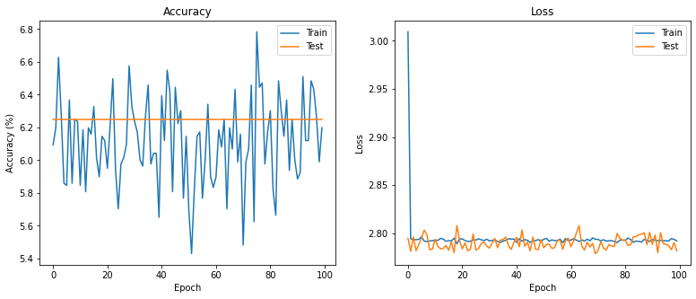

```python
test_network_config(l_r=LEARNING_RATE * 15)
```

#### 03. optimum learning rate

```python
best_acc, best_lr = 0, 0
st, end = LEARNING_RATE * 0.2, LEARNING_RATE * 2
steps = 10
coeff = (end - st) / steps
for c in range(steps):
    _lr = st + c*coeff
    acc = test_network_config(l_r=_lr, ret_acc=True, out=False, plot=False)
    if acc['test'] > best_acc:
        best_acc = acc['test']
        best_lr = _lr
print(f"The best learning rete for this network structure is: {best_lr} with accuracy: {best_acc:.1f}%")
```

```
The best learning rete for this network structure is: 0.0046 with accuracy: 78.5%
```

```python
OPTIMUM_LEARNING_RATE = best_lr
```

### 03. Activation function

We would try following cases:

- Sigmoid
  - normalizes the values in $range=(0, 1)$ and when argument is a large positive or negative value, it' will get close to $0$
  - decreased model's convergence speed
- Hyperbolic Tangent
  - normalizes the values in $range=(-1, 1)$ and also, it's a zero centered function
  - overfitted model extremely
- Leaky ReLU
  - has the best performance
  - converged faster

**Sigmoid and tanh activation functions are not commonly used in deep learning anymore due to several reasons**:

- Saturation: Both *sigmoid* and *tanh* activation functions saturate at their extremes (0 or 1 for sigmoid, -1 or 1 for tanh), the gradients at these extremes become very small:
  - leading to slow or even non-existent weight updates during backpropagation.
- Vanishing gradients: This saturation can also result in the vanishing gradients problem, where the gradients become so small that they are unable to propagate effectively through the network:
  - leading to slow or ineffective learning.
- Non-zero mean: The sigmoid and tanh activation functions have a non-zero mean, which can make it harder for the network to learn the desired mapping between inputs and outputs.
- Rectified linear units (ReLU): ReLU activation functions have become popular in recent years due to their simplicity, computational efficiency, and improved performance compared to sigmoid and tanh.
  - ReLU activation functions are linear for positive inputs and zero for negative inputs, which results in:
    - fast learning
    - avoids the saturation and vanishing gradient problems.
- In conclusion, while sigmoid and tanh activation functions were popular in the early days of neural network research, they are no longer widely used due to their limitations. Instead, ReLU activation functions and its variants have become the standard activation functions for deep learning models.
- **Leaky ReLU** has non zero derivation for negative values, whether **ReLU** has zero:
  - model would converge faster than using ReLU
  - could prevent zero gradient problem that talked before
  - all neurons actively participate in estimating the result (predicting)

```python
activation_based_accuracy = dict()
```

#### 01. Sigmoid

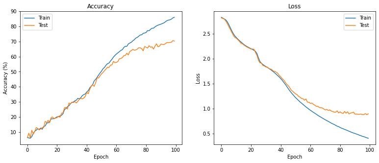

```python
activation_based_accuracy['sigmoid'] = test_network_config(l_r=OPTIMUM_LEARNING_RATE, active=Sigmoid, out=False, ret_acc=True)
```

#### 02. Tanh

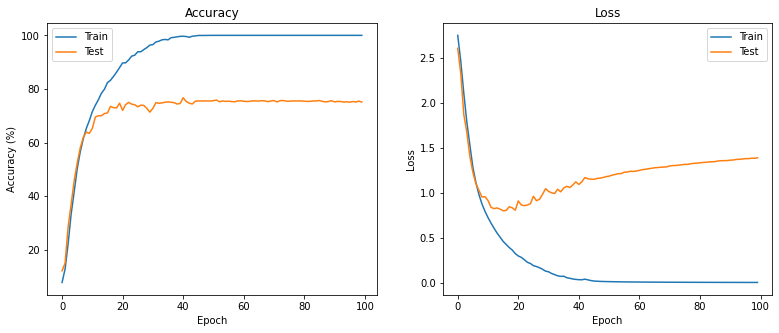

```python
activation_based_accuracy['tanh'] = test_network_config(l_r=OPTIMUM_LEARNING_RATE, active=Tanh, out=False, ret_acc=True)
```

#### 03. Leaky ReLU

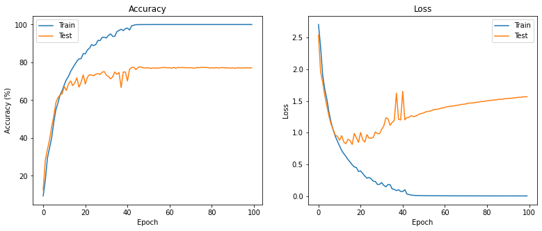

```python
activation_based_accuracy['l_relu'] = test_network_config(l_r=OPTIMUM_LEARNING_RATE, active=LeakyRelu, out=False, ret_acc=True)
```

#### 04. compare accuracy

```python
print("Model      |   Train acc(%)  |  Test Acc(%)")
print("-------------------------------------------")
print(f"Sigmoid   |{activation_based_accuracy['sigmoid']['train']:^17.1f}|{activation_based_accuracy['sigmoid']['test']:^13.1f}")
print(f"Tanh      |{activation_based_accuracy['tanh']['train']:^17.1f}|{activation_based_accuracy['tanh']['test']:^13.1f}")
print(f"Leaky ReLU|{activation_based_accuracy['l_relu']['train']:^17.1f}|{activation_based_accuracy['l_relu']['test']:^13.1f}")
```

```
Model      |   Train acc(%)  |  Test Acc(%)
-------------------------------------------
Sigmoid   |      86.1       |    70.3
Tanh      |      100.0      |    75.1
Leaky ReLU|      100.0      |    77.1
```